# Homework 2: Solution

In this homework, we want to assess the validity of several claims based on the data from Abouir, et al., (2022). First of all, we need to select the observations for different analyses.

```r
library(idarps)
data(codex)

# Cmax
Cmax_men = codex$cmax[codex$gender == 0]
Cmax_women = codex$cmax[codex$gender == 1]
Cmax_non_obese = codex$cmax[codex$obese == 0]
Cmax_obese = codex$cmax[codex$obese == 1]

# Tmax
Tmax_men = codex$tmax[codex$gender == 0]
Tmax_women = codex$tmax[codex$gender == 1]
Tmax_non_obese = codex$tmax[codex$obese == 0]
Tmax_obese = codex$tmax[codex$obese == 1]

# AUC
AUC_men = codex$auc[codex$gender == 0]
AUC_women = codex$auc[codex$gender == 1]
AUC_non_obese = codex$auc[codex$obese == 0]
AUC_obese = codex$auc[codex$obese == 1]
```

### Question 1: Difference between groups for $C_{\max}$

Let’s have a look at the empirical distributions:

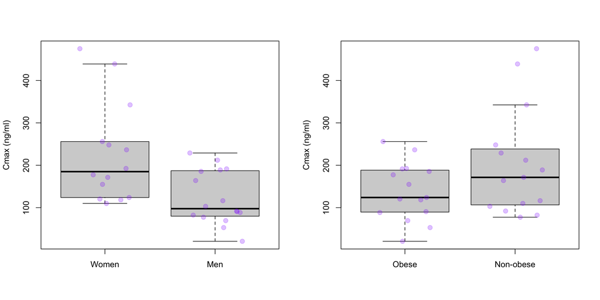

```r
par(mfrow = c(1, 2))
boxplot_w_points(Cmax_women, Cmax_men, names = c("Women", "Men"), ylab = "Cmax (ng/ml)")
boxplot_w_points(Cmax_obese, Cmax_non_obese, names = c("Obese", "Non-obese"), ylab = "Cmax (ng/ml)")
```

Based on these graphs, it is reasonable to believe that some outliers are present. Thus, we select Wilcoxon test to compare the means of the different groups.

```r
wilcox.test(Cmax_men, Cmax_women, alternative = "less")
```

```
##
##  Wilcoxon rank sum exact test
##
## data:  Cmax_men and Cmax_women
## W = 43, p-value = 0.001661
## alternative hypothesis: true location shift is less than 0
```

```r
wilcox.test(Cmax_obese, Cmax_non_obese, alternative = "less")
```

```
##
##  Wilcoxon rank sum exact test
##
## data:  Cmax_obese and Cmax_non_obese
## W = 85, p-value = 0.1335
## alternative hypothesis: true location shift is less than 0
```

For the first test, we can see that the p-value = 0.001661 is smaller than 0.05, which indicates that there is evidence against the null hypothesis in favor of the alternative. Therefore, at the 5% significance level, we reject the null and accept the alternative hypothesis that the mean of the variable `cmax` in the group `men` is smaller than the one in the group `women`. However, for the second test, there isn’t enough evidence to reject the null hypothesis that the means for the variable `cmax` are the same between the groups `obese` and `non_obese`. Interestingly, different conclusions would be obtained if we use a (Welch) t-test:

```r
t.test(Cmax_men, Cmax_women, alternative = "less")
```

```
##
##  Welch Two Sample t-test
##
## data:  Cmax_men and Cmax_women
## t = -2.9365, df = 19.255, p-value = 0.004194
## alternative hypothesis: true difference in means is less than 0
## 95 percent confidence interval:
##       -Inf -42.53625
## sample estimates:
## mean of x mean of y
##  122.8219  226.1786
```

```r
t.test(Cmax_obese, Cmax_non_obese, alternative = "less")
```

```
##
##  Welch Two Sample t-test
##
## data:  Cmax_obese and Cmax_non_obese
## t = -1.7488, df = 21.493, p-value = 0.0473
## alternative hypothesis: true difference in means is less than 0
## 95 percent confidence interval:
##       -Inf -1.107418
## sample estimates:
## mean of x mean of y
##  138.6667  203.4433
```

Indeed, we obtain a p-value smaller than $0.05$ for the second test leading to a different conclusion.

### Question 2: Difference between groups for $T_{\max}$

We proceed similarly for the second question:

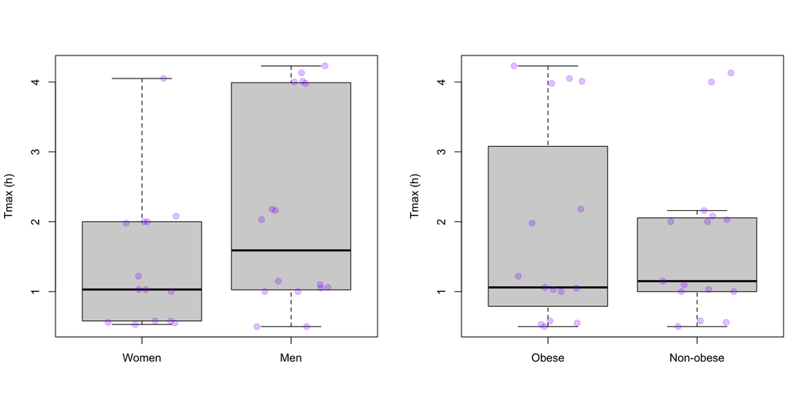

```r
par(mfrow = c(1, 2))
boxplot_w_points(Tmax_women, Tmax_men, names = c("Women", "Men"), ylab = "Tmax (h)")
boxplot_w_points(Tmax_obese, Tmax_non_obese, names = c("Obese", "Non-obese"), ylab = "Tmax (h)")
```

Based on these graphs, we also select Wilcoxon test and obtain the p-values as follows:

```r
wilcox.test(Tmax_men, Tmax_women, alternative = "less")
```

```
##
##  Wilcoxon rank sum test with continuity correction
##
## data:  Tmax_men and Tmax_women
## W = 148, p-value = 0.9356
## alternative hypothesis: true location shift is less than 0
```

```r
wilcox.test(Tmax_obese, Tmax_non_obese, alternative = "less")
```

```
##
##  Wilcoxon rank sum test with continuity correction
##
## data:  Tmax_obese and Tmax_non_obese
## W = 111.5, p-value = 0.4917
## alternative hypothesis: true location shift is less than 0
```

Since both p-values are greater than 0.05, we fail to reject the null hypotheses at the 5% significance level for both tests.

### Question 3: Difference between groups for AUC

We proceed similarly for the last question:

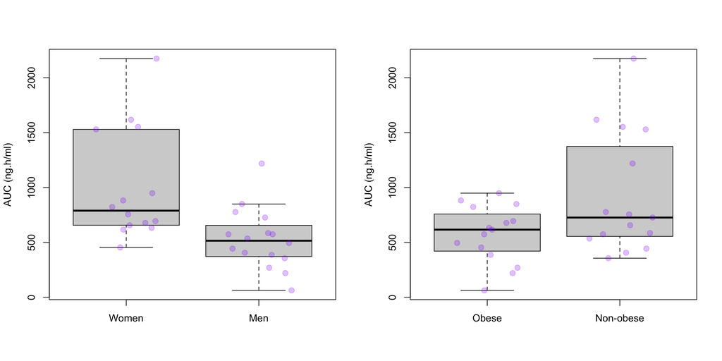

```r
par(mfrow = c(1, 2))
boxplot_w_points(AUC_women, AUC_men, names = c("Women", "Men"), ylab = "AUC (ng.h/ml)")
boxplot_w_points(AUC_obese, AUC_non_obese, names = c("Obese", "Non-obese"), ylab = "AUC (ng.h/ml)")
```

We obtain the p-values as follows:

```r
wilcox.test(AUC_men, AUC_women, alternative = "less")
```

```
##
##  Wilcoxon rank sum exact test
##
## data:  AUC_men and AUC_women
## W = 36, p-value = 0.0005263
## alternative hypothesis: true location shift is less than 0
```

```r
wilcox.test(AUC_obese, AUC_non_obese, alternative = "less")
```

```
##
##  Wilcoxon rank sum exact test
##
## data:  AUC_obese and AUC_non_obese
## W = 78, p-value = 0.08034
## alternative hypothesis: true location shift is less than 0
```

Therefore, for the first test, at the 5% significance level, we reject the null and accept the alternative hypothesis stating that the mean of the variable `auc` in the group `men` is smaller than the one in the group `women`. However, for the second test, there isn’t enough evidence (at the 5% significance level) to reject the null hypothesis that the means for the variable `auc` are the same between the groups `obese` and `non_obese`.